# XGBoost - prezentacja

## Jakub Kosterna

Ku zaprezentowaniu implementacji algorytmu zczytajmy zbiór *Red Wine Quality*.

```python
import pandas as pd
df = pd.read_csv("../data/winequality-red.csv")
df.head()
```

|  | fixed acidity | volatile acidity | citric acid | residual sugar | chlorides | free sulfur dioxide | total sulfur dioxide | density | pH | sulphates | alcohol | quality |
| --- | --- | --- | --- | --- | --- | --- | --- | --- | --- | --- | --- | --- |
| 0 | 7.4 | 0.70 | 0.00 | 1.9 | 0.076 | 11.0 | 34.0 | 0.9978 | 3.51 | 0.56 | 9.4 | 5 |
| 1 | 7.8 | 0.88 | 0.00 | 2.6 | 0.098 | 25.0 | 67.0 | 0.9968 | 3.20 | 0.68 | 9.8 | 5 |
| 2 | 7.8 | 0.76 | 0.04 | 2.3 | 0.092 | 15.0 | 54.0 | 0.9970 | 3.26 | 0.65 | 9.8 | 5 |
| 3 | 11.2 | 0.28 | 0.56 | 1.9 | 0.075 | 17.0 | 60.0 | 0.9980 | 3.16 | 0.58 | 9.8 | 6 |
| 4 | 7.4 | 0.70 | 0.00 | 1.9 | 0.076 | 11.0 | 34.0 | 0.9978 | 3.51 | 0.56 | 9.4 | 5 |

Mamy tu styczność z typowym problemem **klasyfikacji** - będziemy przewidywać jakość wina na podstawie innych kolumn naszej ramki danych.

```python
df["quality"].unique()
```

```
array([5, 6, 7, 4, 8, 3], dtype=int64)
```

Oceny rozpatrywanych czerwonych win jak widać przyjmują 6 wartości - liczby całkowite od 3 do 8. Jaki jest ich rozkład?

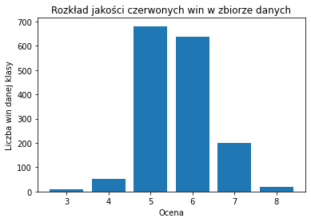

```python
import matplotlib.pyplot as plt
qualities_summed = df.groupby('quality').count().reset_index()[["quality", "alcohol"]]
plt.bar(qualities_summed["quality"], qualities_summed["alcohol"])
plt.title("Rozkład jakości czerwonych win w zbiorze danych")
plt.xlabel("Ocena")
plt.ylabel("Liczba win danej klasy")
plt.show()
```

Jak widać przeważają wina o ocenie 5 i 6, znacznie mniej jest jakości 3, 4, 7 i 8.

Rozdzielmy nasz zbiór na podzbiory treningowy i testowy.

```python
print(df.shape)
test_size = 0.25

X = df.loc[:, df.columns != 'quality']
y = df[['quality']]
from sklearn.model_selection import train_test_split
X_train, X_test, y_train, y_test = train_test_split(X, y, test_size=test_size, random_state = 1613)
print(X_train.shape)
```

```
(1599, 12)
(1199, 11)
```

W efekcie otrzymujemy 1199 obserwacji w biorze treningowym i 400 w zbiorze testowym.

Przejdźmy do realizacji naszego algorytmu. W tym celu wczytajmy pakiet zawierający nasze rozwiązanie. Uwaga! Waży on aż **100 MB.**

```python
import xgboost as xgb
```

W celu realizacji naszego zadania najpierw zbudujemy nasz klasyfikator, żeby potem dopasować go do danych treningowych, a potem przetestować nasze dzieło na zbiorze testowym.

```python
import warnings
warnings.filterwarnings('ignore') # kwestia nieistotnego komunikatu

xgl_model = xgb.XGBClassifier(objective = "multi:softprob", seed = 1613) # w *objective* zaznaczamy, że to klasyfikacja
xgl_model.fit(X_train, y_train["quality"])
preds = xgl_model.predict(X_test)
```

[output not shown]

Czy *XGBoost* aby na pewno jest aż tak fajny jak się o nim mówi?

```python
comparison = pd.DataFrame({'actual':y_test['quality'], 'predicted':preds})
comparison
```

|  | actual | predicted |
| --- | --- | --- |
| 1204 | 7 | 7 |
| 618 | 5 | 6 |
| 845 | 5 | 5 |
| 1154 | 6 | 6 |
| 1174 | 6 | 6 |
| ... | ... | ... |
| 496 | 6 | 6 |
| 260 | 5 | 5 |
| 1498 | 6 | 5 |
| 62 | 7 | 6 |
| 1431 | 6 | 6 |

400 rows × 2 columns

```python
comparison['difference'] = comparison['actual'] - comparison['predicted']
comparison
```

|  | actual | predicted | difference |
| --- | --- | --- | --- |
| 1204 | 7 | 7 | 0 |
| 618 | 5 | 6 | -1 |
| 845 | 5 | 5 | 0 |
| 1154 | 6 | 6 | 0 |
| 1174 | 6 | 6 | 0 |
| ... | ... | ... | ... |
| 496 | 6 | 6 | 0 |
| 260 | 5 | 5 | 0 |
| 1498 | 6 | 5 | 1 |
| 62 | 7 | 6 | 1 |
| 1431 | 6 | 6 | 0 |

400 rows × 3 columns

```python
sum(comparison['difference'] == 0)/400
```

```
0.7
```

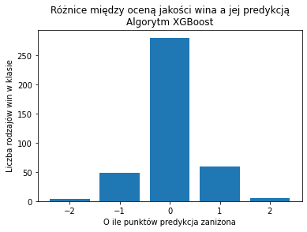

```python
differences_summed = comparison.groupby('difference').count().reset_index()
plt.bar(differences_summed["difference"], differences_summed["actual"])
plt.title("Różnice między oceną jakości wina a jej predykcją\nAlgorytm XGBoost")
plt.xlabel("O ile punktów predykcja zaniżona")
plt.ylabel("Liczba rodzajów win w klasie")
plt.show()
```

Mimo 70% skuteczności oceny jakości win w skali 3-8 co do oceny, w większości pomyłek przewidywana wartość przerosła oczekiwaną o 1 lub -1, niemalże w pojedynczych różnica wyniosła 2 co do modułu, a nigdy więcej - więcej (a przecież mogła być i 5!).

Dla porównania zobaczmy jaki histogram otrzymamy chociażby dla algorytmu k najbliższych sąsiadów.

```
0.505
```

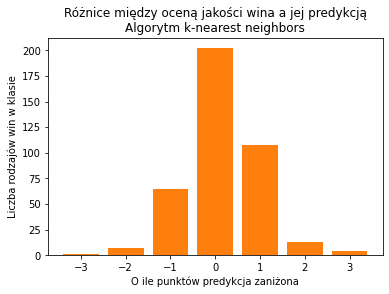

```python
from sklearn.neighbors import KNeighborsClassifier
knn_model = KNeighborsClassifier()
knn_model.fit(X_train, y_train['quality'])
knn_preds = knn_model.predict(X_test)

comparison_knn = pd.DataFrame({'actual':y_test['quality'], 'predicted':knn_preds})
comparison_knn['difference'] = comparison_knn['actual'] - comparison_knn['predicted']

differences_knn_summed = comparison_knn.groupby('difference').count().reset_index()
plt.bar(differences_knn_summed["difference"], differences_knn_summed["actual"])

print(sum(comparison_knn['difference'] == 0)/400)

plt.bar(differences_knn_summed["difference"], differences_knn_summed["actual"])
plt.title("Różnice między oceną jakości wina a jej predykcją\nAlgorytm k-nearest neighbors")
plt.xlabel("O ile punktów predykcja zaniżona")
plt.ylabel("Liczba rodzajów win w klasie")
plt.show()
```

Tutaj wynik jest już stanowczo gorszy - ledwie 50% win zostało poprawnie ocenionych, do tego różnice jednego i dwóch punktów w skali pojawiły się znacznie częściej, a nawet nadwyżki i niedoszacowania o 3 miały miejsce.

A **regresja**? Zobaczmy jak ją napisać i jak się sprawdza na przykładzie zbioru *House Sales in King County, USA*:

https://www.kaggle.com/harlfoxem/housesalesprediction

```python
df_class = pd.read_csv("../data/kc_house_data.csv")
df_class.head()
```

|  | id | date | price | bedrooms | bathrooms | sqft_living | sqft_lot | floors | waterfront | view | ... | grade | sqft_above | sqft_basement | yr_built | yr_renovated | zipcode | lat | long | sqft_living15 | sqft_lot15 |
| --- | --- | --- | --- | --- | --- | --- | --- | --- | --- | --- | --- | --- | --- | --- | --- | --- | --- | --- | --- | --- | --- |
| 0 | 7129300520 | 20141013T000000 | 221900.0 | 3 | 1.00 | 1180 | 5650 | 1.0 | 0 | 0 | ... | 7 | 1180 | 0 | 1955 | 0 | 98178 | 47.5112 | -122.257 | 1340 | 5650 |
| 1 | 6414100192 | 20141209T000000 | 538000.0 | 3 | 2.25 | 2570 | 7242 | 2.0 | 0 | 0 | ... | 7 | 2170 | 400 | 1951 | 1991 | 98125 | 47.7210 | -122.319 | 1690 | 7639 |
| 2 | 5631500400 | 20150225T000000 | 180000.0 | 2 | 1.00 | 770 | 10000 | 1.0 | 0 | 0 | ... | 6 | 770 | 0 | 1933 | 0 | 98028 | 47.7379 | -122.233 | 2720 | 8062 |
| 3 | 2487200875 | 20141209T000000 | 604000.0 | 4 | 3.00 | 1960 | 5000 | 1.0 | 0 | 0 | ... | 7 | 1050 | 910 | 1965 | 0 | 98136 | 47.5208 | -122.393 | 1360 | 5000 |
| 4 | 1954400510 | 20150218T000000 | 510000.0 | 3 | 2.00 | 1680 | 8080 | 1.0 | 0 | 0 | ... | 8 | 1680 | 0 | 1987 | 0 | 98074 | 47.6168 | -122.045 | 1800 | 7503 |

5 rows × 21 columns

```python
X = df_class
X = X.drop(['price', 'id', 'date', 'yr_renovated', 'zipcode', 'lat', 'long'], axis = 1)
y = df_class[['price']]
X_train, X_test, y_train, y_test = train_test_split(X, y, test_size=test_size, random_state = 1613)
print(X.shape)
print(X_train.shape)
```

```
(21613, 14)
(16209, 14)
```

```python
X_train.head()
```

|  | bedrooms | bathrooms | sqft_living | sqft_lot | floors | waterfront | view | condition | grade | sqft_above | sqft_basement | yr_built | sqft_living15 | sqft_lot15 |
| --- | --- | --- | --- | --- | --- | --- | --- | --- | --- | --- | --- | --- | --- | --- |
| 3295 | 3 | 2.25 | 1860 | 15559 | 2.0 | 0 | 0 | 4 | 7 | 1860 | 0 | 1963 | 1110 | 11586 |
| 5152 | 4 | 2.75 | 2080 | 9600 | 1.0 | 0 | 0 | 3 | 8 | 1240 | 840 | 1979 | 1880 | 9525 |
| 11525 | 3 | 1.50 | 2010 | 9480 | 1.0 | 0 | 0 | 3 | 8 | 1570 | 440 | 1951 | 1920 | 8791 |
| 19229 | 3 | 1.50 | 1080 | 2940 | 1.5 | 0 | 0 | 4 | 7 | 1080 | 0 | 1920 | 1400 | 4930 |
| 20858 | 2 | 1.50 | 1440 | 725 | 2.0 | 0 | 0 | 3 | 8 | 1100 | 340 | 2011 | 1440 | 4255 |

```python
xgl_model_class = xgb.XGBClassifier(objective = "reg:linear", seed = 1613)
xgl_model_class.fit(X_train, y_train["price"])
```

[output not shown]

```
XGBClassifier(base_score=0.5, booster='gbtree', colsample_bylevel=1,
              colsample_bynode=1, colsample_bytree=1, gamma=0, gpu_id=-1,
              importance_type='gain', interaction_constraints='',
              learning_rate=0.300000012, max_delta_step=0, max_depth=6,
              min_child_weight=1, missing=nan, monotone_constraints='()',
              n_estimators=100, n_jobs=8, num_parallel_tree=1,
              objective='multi:softprob', random_state=1613, reg_alpha=0,
              reg_lambda=1, scale_pos_weight=None, seed=1613, subsample=1,
              tree_method='exact', validate_parameters=1, verbosity=None)
```

```python
preds = xgl_model_class.predict(X_test)
comparison = pd.DataFrame({'actual':y_test['price'], 'predicted':preds})
comparison
```

|  | actual | predicted |
| --- | --- | --- |
| 20464 | 432500.0 | 395000.0 |
| 1179 | 749950.0 | 625000.0 |
| 2101 | 643000.0 | 500000.0 |
| 13609 | 575000.0 | 305000.0 |
| 20574 | 212000.0 | 345000.0 |
| ... | ... | ... |
| 21161 | 459990.0 | 502000.0 |
| 2453 | 306000.0 | 608000.0 |
| 6418 | 795000.0 | 850000.0 |
| 9377 | 405000.0 | 387000.0 |
| 6911 | 790000.0 | 725000.0 |

5404 rows × 2 columns

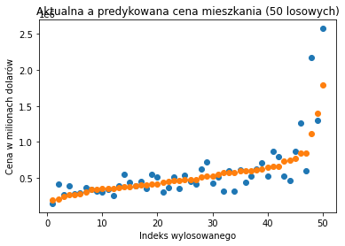

```python
comparison_sample = comparison.sample(50, random_state = 1623)
comparison_sample = comparison_sample.sort_values("predicted")
plt.scatter(range(1,51), comparison_sample['actual'])
plt.scatter(range(1,51), comparison_sample['predicted'])
plt.title("Aktualna a predykowana cena mieszkania (50 losowych)")
plt.xlabel("Indeks wylosowanego")
plt.ylabel("Cena w milionach dolarów")
plt.show()
```

```python
from sklearn.metrics import mean_squared_error
import math
rms = mean_squared_error(comparison['actual'], comparison['predicted'], squared=False)
print(rms)
print(math.sqrt(rms))
```

```
245782.465754119
495.76452651850656
```

```python
import scipy.stats
corr =  scipy.stats.pearsonr(comparison['actual'], comparison['predicted'])[0]
print(corr)
```

```
0.7158735994848562
```

Bardzo satysfakcjonujący wynik!

Jak działać dla innych przypadków uczenia nadzorowanego? Po prostu **zmieniamy parametr *objective***! Dla przykładu

- *reg:logistic* dla klasyfikacji binarnej
- *binary:logistic* dla klasyfikacji binarnej, ale z prawdopodobieństwami zamiast konkretnych rozwiązań
- *reg:linear* dla regresji
- itd...

Oczywiście można też dokonać tuningu *hyperparametrów*; godne uwagi chociażby **max_depth** czy **booster**.